--- title: "Coursework 1 " author: "Aloka Sisilal De silva" student_id: "201519348" format: html: code-fold: false ---

# **Introduction**

This computational essay will about discuss the **Chicago Region** in the *Illinois* State in the *United States of America*. The data on the map will be plotted using information about **Educational Facilities** and **Student Performance** in the State. The maps will be generated by retrieving data through various APIs and styled using *Mapbox* and *Choropleths*. Further details about the displayed map and the reasons for the conclusions drawn, will be discussed in the writing.

# **Importing Packages**

```python
import folium
import pandas as pd
import geopandas as gpd
import requests
import json
import time
import matplotlib.pyplot as plt
import matplotlib as mpl
import seaborn as sns
```

# **Retrieving The Shape File**

First a shape file was retrieved from [USA Government Data](https://catalog.data.gov/dataset/boundaries-zip-codes) that contained location data about Chicago. The shape file simply contained the boudaries of each zip code and the geometry was in *MULTIPOLYGON*. First the CRS of the base map was set to the CRS *EPSG 4326*. The decison to use this crs is, according to Jurkowska (2023) due to reasons such as,

- Being Widely Adopted in the World
- Applicable for Global usage since it covers the Entire earth
- Not having Disortion issues of Web Mercator

Next the Chicago shape file was simply plotted using the `plot` command from the `matplotlib` *python library* .

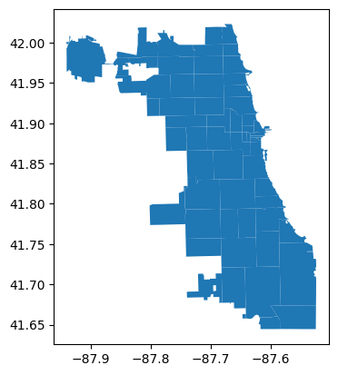

```python
chicago_shape = gpd.read_file("../asg_data/geo_export_70ca3f92-189d-4d1b-b278-7adc0e3d1917.shp")
chicago_shape.head()

#Setting the CRS to USA Data
wgs = 'EPSG:4326'
chicago_shape.to_crs(wgs, inplace = True)
chicago_shape["id_str"] = chicago_shape.index.astype(str)

#plotting the base map to have an idea about the shape of the map we are going to working with.
chicago_shape.plot()
```

# **Retrieving Data Using APIs**

## **Calling Cleaning and Plotting Data About School**

### **School Data from the API**

The **Spatial Data Frame** retrieved from the API includes **The 2013 School Progress Report Card data elements for each CPS high school, offering an annual summary of the school's performance.** The code snippet below fetches the data through the API, converts it to String Format, and then outputs it using a `for loop` to get a general sense of the dataset content, helping in identifying outliers and crucial points for subsequent analysis.

```python
#Reading data from the API
school_data_response = requests.get("https://data.cityofchicago.org/resource/2m8w-izji.json")
#library_data_response.json()

#The data is in bytes So, Converted them in to String
school_data = school_data_response.content.decode('utf-8')
school_data = json.loads(school_data)

#checking the format of data we get from the API to decide what to clean up.
#for school_branch_data in school_data:
    #for key, value in school_branch_data.items():
        #print(f"{key}: {value}")

    #print("\n")
```

### **Cleaning Data About School To Suit Our Analysis**

#### **Importance of EPAS Growth Percentile**

The *Student Growth Percentile (SGP)* is a scale used to measure academic performance of students comapred to their peers in similar academic level (Renaissance Learning, n.d). These results might help guide decisions about schooling and are frequently utilised for assessment reasons. For example, lower percentile ratings may indicate that a student needs specialised help in a given area. The outcomes of these evaluations provide teachers the ability to pinpoint particular problems that require attention and to schedule timely interventions (Logsdon, 2023). With these reasoning the analysis were decided to be carried on the Growth Percentile rate of the high schools in the region to find out the schools performance based on their students grades.

```python
# Creating  a pandas data frame from the data read
school_data_df = pd.DataFrame(school_data)

#school_data_df['epas_attainment_percentile']
#school_data_df

# Selecting specific columns to be kept for analysis and dropping the rest
selected_columns = ['school_id', 'name_of_school', 'city', 'zip', 'epas_attainment_percentile','latitude','longitude']
cleaned_school_data_df = school_data_df.loc[:, selected_columns]
cleaned_school_data_df = cleaned_school_data_df.dropna(subset=['epas_attainment_percentile'])

print(cleaned_school_data_df.head())
```

```
  school_id                                     name_of_school     city  \
1    400133            YCCS-Innovations of Arts Integration HS  Chicago
2    400148   Instituto Justice and Leadership Acad Charter HS  Chicago
3    609761                       George H Corliss High School  Chicago
4    609716                            Kelvyn Park High School  Chicago
5    400010  Architecture, Construction, and Engineering(AC...  Chicago

     zip epas_attainment_percentile      latitude    longitude
1  60609                          7  -87.63197673   41.8118729
2  60608                          8  -87.68406506  41.84547684
3  60628                          5  -87.60307842  41.70739096
4  60639                         14  -87.73600171  41.92789092
5  60609                          9  -87.62588513  41.79609702
```

### **Processing data about schools.**

Next the data was grouped by the zip code and calculated the mean *Growth Percentile* for each zip code. Few reasons for using the *mean* value to group the data are,

- Since mean uses the whole data for the selected variable it supports in good representation of data.(Manikandan, 2011)
- Mean helps to measure central tendency.(Manikandan, 2011)
- Robust and moderate against outliers.

```python
# epas_attainment_percentile column to int and groupings
cleaned_school_data_df['epas_attainment_percentile'] = cleaned_school_data_df['epas_attainment_percentile'].astype(int)
average_percentile_by_zip = cleaned_school_data_df.groupby('zip')['epas_attainment_percentile'].mean().reset_index()
print(average_percentile_by_zip.head())
```

```
     zip  epas_attainment_percentile
0  60602                   68.000000
1  60605                   98.000000
2  60607                   69.500000
3  60608                   22.875000
4  60609                   13.666667
```

### **Plotting Mean Growth Percentile per ZIP Code**

#### **Merging filtered data with the shape file**

The shape file was combined with the `average_percentile_by_zip` dataframe so that the result will contain *geometry and mean growth percentile* for each zip code.

```python
school_combined_df = pd.merge(average_percentile_by_zip, chicago_shape, on='zip', how='left')

#dropping NA columns
school_combined_df = school_combined_df.dropna(subset=['objectid'])
print(school_combined_df.head())
```

```
     zip  epas_attainment_percentile  objectid    shape_area     shape_len  \
0  60602                   68.000000      26.0  4.847125e+06  14448.174993
1  60605                   98.000000      20.0  3.630128e+07  37973.346105
2  60607                   69.500000      29.0  6.466429e+07  39143.639517
3  60608                   22.875000      28.0  1.765055e+08  53169.217720
4  60609                   13.666667      22.0  2.134903e+08  58540.920413

                                            geometry id_str
0  POLYGON ((-87.60997 41.88436, -87.60997 41.884...     40
1  POLYGON ((-87.62064 41.87705, -87.61740 41.877...     34
2  POLYGON ((-87.63962 41.87677, -87.63928 41.876...     43
3  POLYGON ((-87.64671 41.85991, -87.64670 41.859...     42
4  POLYGON ((-87.62665 41.83091, -87.62664 41.830...     36
```

#### **Plotting the Map**

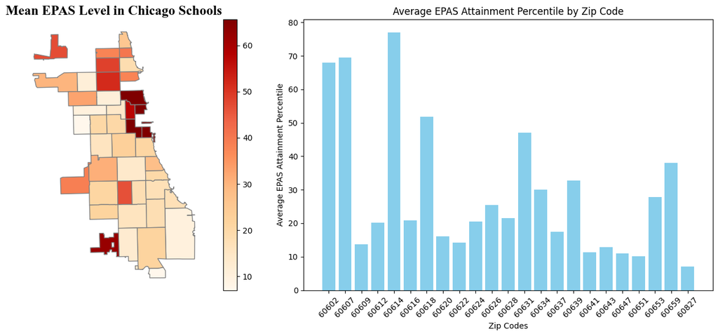

```python
# DF to GDF
school_combined_gdf = gpd.GeoDataFrame(school_combined_df, geometry='geometry')
vmax = school_combined_gdf['epas_attainment_percentile'].quantile(0.90)
norm = mpl.colors.Normalize(vmin=school_combined_gdf['epas_attainment_percentile'].min(), vmax=vmax)

# Plotting map
fig, ax = plt.subplots(1, 2, figsize=(15, 6))  # 1 row, 2 columns

ax[0].set_axis_off()
school_combined_gdf.plot(ax=ax[0], column='epas_attainment_percentile', cmap='OrRd', legend=True, norm=norm, edgecolor='grey')
title_parameters = {'fontsize': '17', 'fontname': 'Times New Roman', 'fontweight': 'bold'}
ax[0].set_title("Mean EPAS Level in Chicago Schools", **title_parameters)

n = 2  # Display every nth zip code
ax[1].bar(average_percentile_by_zip['zip'][::n], average_percentile_by_zip['epas_attainment_percentile'][::n], color='skyblue')
ax[1].set_xlabel('Zip Codes')
ax[1].set_ylabel('Average EPAS Attainment Percentile')
ax[1].set_title('Average EPAS Attainment Percentile by Zip Code')
ax[1].tick_params(axis='x', rotation=45)
plt.tight_layout()
plt.show()
```

### **Analysis on the static map on Mean EPAS Level in Chicago Schools**

The code snippet calculates the 90th percentile (0.90 quantile) of the 'epas_attainment_percentile' column and uses this value to plot the above map. The `vmax` value obtained from the 90th percentile helps in setting the upper limit for colour normalization, ensuring that the map highlights areas with higher attainment levels while maintaining variation in the data.

As it can be obveserved in the map there is quite a good variation/ spread of how students of school perform in different zip codes. The upper area of Chicago seems to have schools that tend to perform well based on the Mean Growth Percentile Level suggesting the majority of well performing schools tend to be in those specific zip codes. The bar chart represents Average EPAS Attainment Percentile by Zip Code for every nth zip code. *{Did not plot every zip code to minimze clutter.}*

Accoring the Development Bank of Latin America and the Caribbean (2016), performance of these schools in specific regions can be dependent on several factors such as,

- Safe and Supportive Environment.
- Infrastructures and Facilites around the Area
- Cultural Emphasis within the area

Well-maintained infrastructure providing comfortable, quiet study spaces with readily available resources can significantly enhance the learning experience for students, fostering academic engagement and potentially leading to improved academic performance. When speaking on educational infrastructure the first things pops up to ones mind is having good library facilities.

Libraries offer vital resources, support networks, and a stimulating atmosphere that may both directly and indirectly raise student achievement. They are an integral aspect of the educational infrastructure. Libraries handle resource constraints, provide concentrated study places, encourage literacy, and give instructional assistance in order to help students succeed in a variety of academic subjects (Lance & E. Kachel, 2023).

Therefore the decission was taken to see the relationship on how infrastructure fascilites such as libraries improve student Performance. With that reasoning the following steps explained the computational essay was carried out.

## **Calling Cleaning and Plotting Data About Libraries**

### **Library Data from the API**

The **Spatial Data Frame** retrieved from the API includes **Total library visitors in Chicago for the Year 2023** The code snippet below fetches the data through the API, converts it to String Format. The total number of visitors to the library reflects the actual library visitors, not the foot traffic or visitors in the vicinity.

```python
#Reading data from the API
library_data_response = requests.get("https://data.cityofchicago.org/resource/ykhx-yxn9.json")
#library_data_response.json()

#The data is in bytes So, Converted them in to String
library_data = library_data_response.content.decode('utf-8')
library_data = json.loads(library_data)

#checking the format of data we get from the API to decide what to clean up.
#for branch_data in library_data:
    #for key, value in branch_data.items():
        #print(f"{key}: {value}")

    #print("\n")
```

### **Cleaning Data About Libraries To Suit Our Analysis**

From the `json` data received from the above API call it is important to extract the data that will be needed for our analysis. After converting the data into `pandas dataframe` it was observed that the latitude and the longitude was not directly available as a columm. Therfore, they were put into columns the outlier columns were dropped and the NA values were discarded to have a clean dataframe that will help for a clean analysis to be carried out. The relevant steps are conducted using the below code snippet.

After cleaning the dataframe will contain information such as **"branch name", "address", "zip", "visitors per each month", "latitude and longitude coordinates"** about different libraries in Chicago.

```python
library_data_df = pd.DataFrame(library_data)

# Latitude Longitude not in correct order . Ectracting them from the json and putting them into seperate columns
library_data_df['latitude'] = library_data_df['location'].apply(lambda loc: loc.get('coordinates')[1] if loc else None)
library_data_df['longitude'] = library_data_df['location'].apply(lambda loc: loc.get('coordinates')[0] if loc else None)

#Computed region data not needed. The locsation data cn be removed because the latitude and longitude was extracted.
prefix_to_drop = ':@computed_region'
columns_to_drop = [col for col in library_data_df.columns if col.startswith(prefix_to_drop)]
library_data_cleaned_df = library_data_df.drop(columns=columns_to_drop, errors='ignore')
library_data_cleaned_df = library_data_cleaned_df.drop(columns="location", errors='ignore')

print(library_data_cleaned_df.head())
```

```
           branch                  address     city    zip january february  \
0     Albany Park      3401 W. Foster Ave.  Chicago  60625    3419     6208
1         Altgeld         955 E. 131st St.  Chicago  60827     339      822
2  Archer Heights      5055 S. Archer Ave.  Chicago  60632    2949     2360
3          Austin        5615 W. Race Ave.  Chicago  60644    2991     2312
4   Austin-Irving  6100 W. Irving Park Rd.  Chicago  60634    3101     3642

  march april   may  june  july august september october november december  \
0  8004  6925  7068  6394  7005   6848      7061    6955     6719     6469
1  3378  3231  3217  3466  4771   4217      4146    4613     3542     3204
2  3250  3169  2896  4950  3198   3390      3329    4599     5054     2703
3  3410  3486  1636  3883  5135   4145      3804    3918     3492     2982
4  4957  4893  4326  5147  5029   5149      4840    5656     5303     3944

     ytd  latitude  longitude
0  79075  41.97570  -87.71357
1  38946  41.65728  -87.59861
2  41847  41.80070  -87.72663
3  41194  41.88929  -87.76597
4  55987  41.95301  -87.77944
```

### **Processing data about libraries.**

#### **Getting Total Number Visitors Per Each Library**

1. The availability of physical materials like books and multimedia resources.
2. Access to digital resources such as online databases and eBooks.
3. Quiet and conducive study spaces that enhance the student experience.

These and other features can attract more students, offering them an enhanced educational experience that can lead to better performance and higher scores, consequently driving the Growth Percentile of regions. Nonetheless, this is not always the case, and as we progress through the computational essay, more insights will be shared regarding these factors.

```python
months = ['january', 'february', 'march', 'april', 'may', 'june', 'july', 'august', 'september', 'october', 'november', 'december']

#Converting the months vistors to numeric since we convereted the whole df to utf 8
library_data_cleaned_df[months] = library_data_cleaned_df[months].apply(pd.to_numeric, errors='coerce')

# Insert sum of total visitors for 12months per each branch into a new column
library_data_cleaned_df['total_visitors_per_year'] = library_data_cleaned_df[months].sum(axis=1, skipna=True)
print(library_data_cleaned_df[['branch', 'total_visitors_per_year']].head())
```

```
           branch  total_visitors_per_year
0     Albany Park                    79075
1         Altgeld                    38946
2  Archer Heights                    41847
3          Austin                    41194
4   Austin-Irving                    55987
```

```python
#Grouping the data byu zip code
group_library_by_zip_df = library_data_cleaned_df.groupby('zip')['total_visitors_per_year'].sum().reset_index()
print(group_library_by_zip_df.head())
```

```
     zip  total_visitors_per_year
0  60605                   686752
1  60607                   138088
2  60608                    63295
3  60609                   123329
4  60610                    61030
```

### **Plotting Total Yearly Visiotrs Per Annum per ZIP Code**

#### **Merging filtered data with the shape file**

```python
# Merging with zip coides
library_combined_df = pd.merge(group_library_by_zip_df, chicago_shape, on='zip', how='left')

# Display the resulting dataframe
print(library_combined_df.head())
```

```
     zip  total_visitors_per_year  objectid    shape_area     shape_len  \
0  60605                   686752      20.0  3.630128e+07  37973.346105
1  60607                   138088      29.0  6.466429e+07  39143.639517
2  60608                    63295      28.0  1.765055e+08  53169.217720
3  60609                   123329      22.0  2.134903e+08  58540.920413
4  60610                    61030      54.0  3.159816e+07  24208.698879

                                            geometry id_str
0  POLYGON ((-87.62064 41.87705, -87.61740 41.877...     34
1  POLYGON ((-87.63962 41.87677, -87.63928 41.876...     43
2  POLYGON ((-87.64671 41.85991, -87.64670 41.859...     42
3  POLYGON ((-87.62665 41.83091, -87.62664 41.830...     36
4  POLYGON ((-87.62820 41.89668, -87.62820 41.896...     53
```

#### **Plotting the Map**

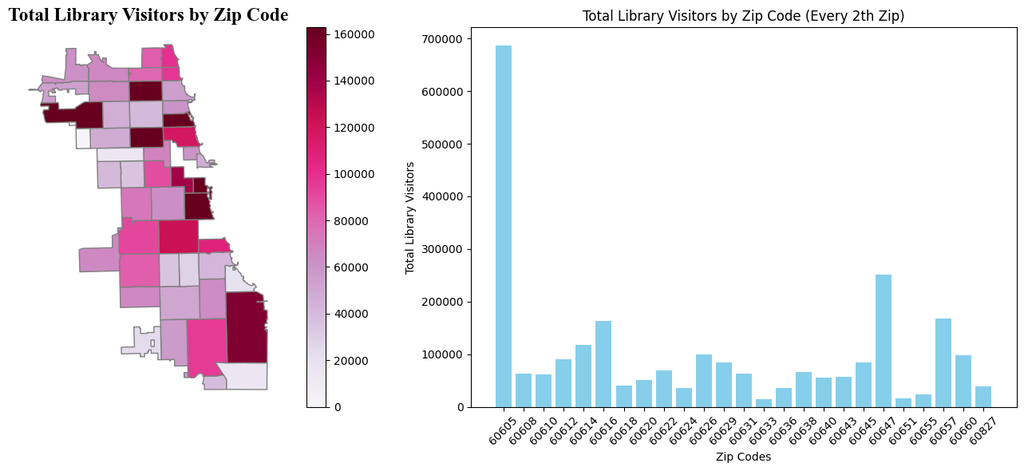

```python
# Convert DataFrame to GeoDataFrame for library data
library_combined_gdf = gpd.GeoDataFrame(library_combined_df, geometry='geometry')

# Quantiles for library data
vmax_library = library_combined_gdf['total_visitors_per_year'].quantile(0.90)
norm_library = mpl.colors.Normalize(vmin=library_combined_gdf['total_visitors_per_year'].min(), vmax=vmax_library)

# Plotting both the map and bar chart side by side with simplified x-axis
fig, ax = plt.subplots(1, 2, figsize=(15, 6))

# Plot visitors map
ax[0].set_axis_off()
library_combined_gdf.plot(ax=ax[0], column='total_visitors_per_year', cmap='PuRd', legend=True, norm=norm_library, edgecolor='grey')
title_parameters = {'fontsize': '17', 'fontname': 'Times New Roman', 'fontweight': 'bold'}
ax[0].set_title("Total Library Visitors by Zip Code", **title_parameters)

# Plot bar chart
n = 2
ax[1].bar(group_library_by_zip_df['zip'][::n], group_library_by_zip_df['total_visitors_per_year'][::n], color='skyblue')
ax[1].set_xlabel('Zip Codes')
ax[1].set_ylabel('Total Library Visitors')
ax[1].set_title('Total Library Visitors by Zip Code (Every {}th Zip)'.format(n))
ax[1].tick_params(axis='x', rotation=45)

plt.tight_layout()
plt.show()
```

### **Analysis on the static map on Annual Total Visitors for Chicago Libraries**

As per the above writing, various reasons can have affected towards the visitor count per library. However, when observing the bar chart it can be identified that the disribution of visitors are not quite even. Suggesting inequal distrubution of infrastructures which will directly effect the visitor base of a library in a paticular zip code.

## **Comapring To Discover Patterns**

Simply plotting the two maps generated above side by side

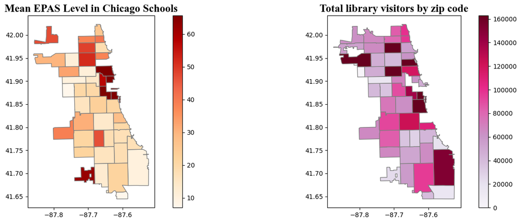

```python
fig, axs = plt.subplots(1, 2, figsize=(15, 5))

# Map 1
vmin = school_combined_gdf['epas_attainment_percentile'].min()
vmax = school_combined_gdf['epas_attainment_percentile'].quantile(0.90)
norm = mpl.colors.Normalize(vmin=vmin, vmax=vmax)
#axs[0].set_axis_off()
school_combined_gdf.plot(ax=axs[0], column='epas_attainment_percentile', cmap='OrRd', legend=True, norm=norm, edgecolor='grey')
title_parameters = {'fontsize': '17', 'fontname': 'Times New Roman', 'fontweight': 'bold'}
axs[0].set_title("Mean EPAS Level in Chicago Schools", **title_parameters)

vmin = library_combined_gdf['total_visitors_per_year'].min()
vmax = library_combined_gdf['total_visitors_per_year'].quantile(0.90)
norm = mpl.colors.Normalize(vmin=vmin, vmax=vmax)
#axs[1].set_axis_off()
library_combined_gdf.plot(ax=axs[1], column='total_visitors_per_year', cmap='PuRd', legend=True, norm=norm, edgecolor='grey')
title_parameters = {'fontsize': '17', 'fontname': 'Times New Roman', 'fontweight': 'bold'}
axs[1].set_title("Total library visitors by zip code", **title_parameters)

plt.tight_layout()
plt.show()
```

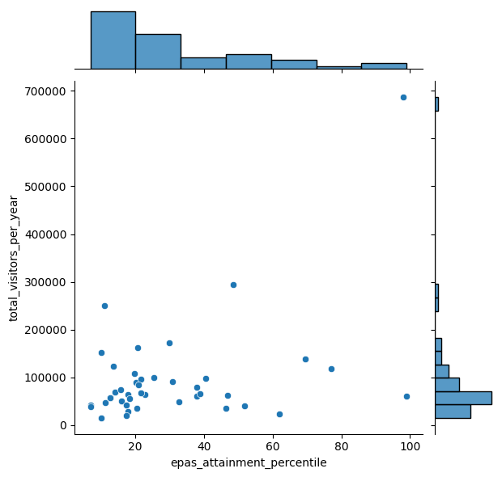

```python
mergedf = pd.merge(school_combined_df, library_combined_df, on='zip', how='left')
mergedf

sns.jointplot(x='epas_attainment_percentile', y='total_visitors_per_year', data=mergedf, kind='scatter')
plt.show()
```

# **Building an Interactive Map**

From this point onwards the Computational Essay will Focus On Getting the Above mentioned relationships to an Interactive Map making it convey the message discussed throughout this computational essay.

### **Plotting the initial map**

```python
# Mapbox tile URL

# Define the location of Chicago
chicago_location = (41.8580, -87.6094)

mapbox_access_token = 'pk.eyJ1IjoicHNhZGVzaWwiLCJhIjoiY2xzdnB2Z3hnMHB4djJpcXRyY2FtZ3dqNiJ9.5K-bts-RCo4I0rtbcNknPQ'

#tile_url = f'https://api.mapbox.com/styles/v1/mapbox/traffic-day-v2/tiles/{{z}}/{{x}}/{{y}}?access_token={mapbox_access_token}'#

#chicago_map = folium.Map(location=chicago_location, zoom_start=10.5, tiles = tile_url, attr='Mapbox')

mapbox_style_url = "https://api.mapbox.com/styles/v1/psadesil/clt61y48g005t01qran6h1lof/tiles/256/{z}/{x}/{y}@2x?access_token=pk.eyJ1IjoicHNhZGVzaWwiLCJhIjoiY2xzdnB2Z3hnMHB4djJpcXRyY2FtZ3dqNiJ9.5K-bts-RCo4I0rtbcNknPQ"

chicago_map = folium.Map(location=chicago_location, zoom_start=9.5, tiles=mapbox_style_url, attr="Mapbox", control_scale=True)

chicago_map

# Define a color scheme for EPAS Percentile rate
fill_color = "YlOrRd"


# Add Choropleth layer with quartiles classification
epas_choro = folium.Choropleth(
    geo_data=chicago_shape,
    data=school_combined_df,
    columns=("zip", "epas_attainment_percentile"),
    key_on="feature.properties.zip",
    fill_color=fill_color,
    nan_fill_color='white',
    line_weight=0.8,
    line_color='black',
    fill_opacity=0.8,
    legend_name="Mean Growth Percentile",
    highlight=True,
    threshold_scale=[school_combined_df["epas_attainment_percentile"].quantile(q=i/7) for i in range(8)],
).add_to(chicago_map)

def style_function(feature):
    return {
        "color": "transparent",
        "fillColor": "transparent",
    }

tooltip = folium.features.GeoJsonTooltip(fields=("epas_attainment_percentile",), aliases=("Mean Growth Percentile",))
tooltip_layer = folium.features.GeoJson(school_combined_gdf, style_function=style_function, tooltip=tooltip)
tooltip_layer.add_to(chicago_map)
#chicago_map
```

```
<folium.features.GeoJson at 0x16a1f4e50>
```

### **Plotting The Top 5 Libraries in Chicago Based on the Total Annual Visitors**

```python
top_libraries_df = library_data_cleaned_df.sort_values(by='total_visitors_per_year', ascending=False).head(5)

# Display the top libraries DataFrame
print(top_libraries_df)
# Add markers for each library in the DataFrame
for index, row in top_libraries_df.iterrows():
    location_coordinates = (row['latitude'], row['longitude'])
    library_icon = folium.Icon(icon='book', prefix='fa')

    # Customize the popup content with branch name, total visitors, and address
    popup_content = f"<div style='width: 200px;'><b>Branch Name:</b> {row['branch']}<br>" \
                    f"<b>Total Visitors Per Year:</b> {row['total_visitors_per_year']}<br>" \
                    f"<b>Address:</b> {row['address']}</div>"

    folium.Marker(location=location_coordinates, popup=popup_content, icon=library_icon).add_to(chicago_map)

    legend_html = """
     <div style="position: fixed;
                 bottom: 30px; right: 50px; width: 300px; height: 180px;
                 border:2px solid grey; z-index:9999; font-size:12px;
                 background-color:white;
                 ">&nbsp; <b>What do the markers mean</b><br>
                  &nbsp; <i class="fa fa-book fa-2x"
                  style="color:blue"></i>
                  &nbsp; Top 5 Libraries by visiotrs <br>
                   &nbsp; <i class="fa fa-book fa-2x"
                  style="color:green"></i>
                  &nbsp; Other Libraries with Low No. of Visitors <br>
                   &nbsp; <i class="fa fa-book fa-2x"
                  style="color:orange"></i>
                  &nbsp; Other Libraries with Medium No. of Visitors <br>
                   &nbsp; <i class="fa fa-book fa-2x"
                  style="color:red"></i>
                  &nbsp; Other Libraries with High No. of Visitors <br>
                 &nbsp; <i class="fa fa-school fa-2x"
                  style="color:grey"></i>
                 &nbsp; ZIP Codes with lowest Mean Growth Percentile
      </div>
     """

chicago_map.get_root().html.add_child(folium.Element(legend_html))

# Display the map
#chicago_map
```

```
                               branch                 address     city    zip  \
31  Harold Washtington Library Center        400 S. State St.  Chicago  60605
64            Sulzer Regional Library    4455 N. Lincoln Ave.  Chicago  60625
17                          Chinatown  2100 S. Wentworth Ave.  Chicago  60616
41                       Lincoln Park  1150 W. Fullerton Ave.  Chicago  60614
44                       Logan Square  3030 W. Fullerton Ave.  Chicago  60647

    january  february  march  april    may   june   july  august  september  \
31    39287     50081  64622  64754  60950  63316  71029   65825      61361
64    13873     15111  19899  18966  17119  14966  18748   19294      18776
17     2963      6955  11013  11999  13147  15962  16974   15109      13290
41     4915      6552   8399   9454   9152  12512  10660   10414       8960
44     7285      8572  10957  10380   9038   9187  10600   11057       9856

    october  november  december     ytd  latitude  longitude  \
31    67126     50053     28348  686752  41.87633  -87.62763
64    21154     20568     16373  214847  41.96267  -87.68467
17    14005     11877     11473  144767  41.85419  -87.63181
41    11785     17248      8067  118118  41.92529  -87.65805
44    10579     10006      9037  116554  41.92476  -87.70341

    total_visitors_per_year
31                   686752
64                   214847
17                   144767
41                   118118
44                   116554
```

```
<branca.element.Element at 0x148275c50>
```

The map currently showcases information on the top 5 libraries in Chicago, highlighting their total annual visitors through interactive `tool tips`. By clicking on these `tool tips`, viewers can access additional details about each specific library. The rationale behind this approach will be elucidated after presenting the final map.

```python
library_data_dropped_df = library_data_cleaned_df[~library_data_cleaned_df['branch'].isin(top_libraries_df['branch'])]


print(library_data_dropped_df.head())
print(library_data_dropped_df['total_visitors_per_year'].mean())
```

```
           branch                  address     city    zip  january  february  \
0     Albany Park      3401 W. Foster Ave.  Chicago  60625     3419      6208
1         Altgeld         955 E. 131st St.  Chicago  60827      339       822
2  Archer Heights      5055 S. Archer Ave.  Chicago  60632     2949      2360
3          Austin        5615 W. Race Ave.  Chicago  60644     2991      2312
4   Austin-Irving  6100 W. Irving Park Rd.  Chicago  60634     3101      3642

   march  april   may  june  july  august  september  october  november  \
0   8004   6925  7068  6394  7005    6848       7061     6955      6719
1   3378   3231  3217  3466  4771    4217       4146     4613      3542
2   3250   3169  2896  4950  3198    3390       3329     4599      5054
3   3410   3486  1636  3883  5135    4145       3804     3918      3492
4   4957   4893  4326  5147  5029    5149       4840     5656      5303

   december    ytd  latitude  longitude  total_visitors_per_year
0      6469  79075  41.97570  -87.71357                    79075
1      3204  38946  41.65728  -87.59861                    38946
2      2703  41847  41.80070  -87.72663                    41847
3      2982  41194  41.88929  -87.76597                    41194
4      3944  55987  41.95301  -87.77944                    55987
42489.71052631579
```

### **Plotting the rest of the libraries in Chicago Based on the Total Annual Visitors**

Next the rest of the libraries apart from the top 5, was plotted and they were colour graded and divided into three divisions based on the mean of total visitors.

```python
from folium.plugins import MarkerCluster
# Define a function to assign colors based on total visitors
def assign_color(total_visitors):
    if total_visitors < 33000:
        return 'green'  # Low
    elif 10000 <= total_visitors < 43000:
        return 'orange'  # Mid
    else:
        return 'red'  # High

# Create a MarkerCluster to group nearby markers
marker_cluster = MarkerCluster().add_to(chicago_map)

for index, row in library_data_dropped_df.iterrows():
    location_coordinates = (row['latitude'], row['longitude'])

    # Use the assign_color function to determine the marker color
    marker_color = assign_color(row['total_visitors_per_year'])

    library_icon = folium.Icon(icon='book', prefix='fa', color=marker_color)

    # Customize the popup content with branch name, total visitors, and address
    popup_content = f"<div style='width: 200px;'><b>Branch Name:</b> {row['branch']}<br>" \
                    f"<b>Total Visitors Per Year:</b> {row['total_visitors_per_year']}<br>" \
                    f"<b>Address:</b> {row['address']}</div>"


    folium.Marker(location=location_coordinates, popup=popup_content, icon=library_icon).add_to(marker_cluster)
```

### **Pointing Out The Zip codes with Minimum Mean Growth Percentile**

```python
low_epa_zip = average_percentile_by_zip.sort_values(by='epas_attainment_percentile', ascending=True).head(2)
low_epa_zip
target_zip_code_1 = '60827'
target_zip_code_2 = '60644'

geometry_of_target_zip_1 = school_combined_df.loc[school_combined_df['zip'] == target_zip_code_1]
geometry_of_target_zip_2 = school_combined_df.loc[school_combined_df['zip'] == target_zip_code_2]
print(geometry_of_target_zip_1)
print(geometry_of_target_zip_2)

#Marking the Zip Code with the lowest Mean
lowest_value_row_1 = cleaned_school_data_df.loc[cleaned_school_data_df['zip'] == target_zip_code_1].min()
# Extract the latitude and longitude values
lowest_value_latitude_1 = lowest_value_row_1['latitude']
lowest_value_longitude_1 = lowest_value_row_1['longitude']
popup_content_1 = f"<div style='width: 150px;'><b>Zip code with lowest Mean Growth Percentile</b></div>"
school_icon = folium.Icon(icon='school', prefix='fa', color = 'black')
folium.Marker(location=[lowest_value_longitude_1,lowest_value_latitude_1], popup= popup_content_1, icon=school_icon).add_to(chicago_map)

#Marking the Zip Code with the 2nd lowest Mean
lowest_value_row_2 = cleaned_school_data_df.loc[cleaned_school_data_df['zip'] == target_zip_code_2].min()
lowest_value_latitude_2 = lowest_value_row_2['latitude']
lowest_value_longitude_2 = lowest_value_row_2['longitude']
popup_content_2 = f"<div style='width: 150px;'><b>Zip code with second lowest Mean Growth Percentile</b></div>"
school_icon = folium.Icon(icon='school', prefix='fa', color = 'black')
folium.Marker(location=[lowest_value_longitude_2,lowest_value_latitude_2], popup= popup_content_2, icon=school_icon).add_to(chicago_map)

#chicago_map
```

```
      zip  epas_attainment_percentile  objectid    shape_area     shape_len  \
45  60827                         7.0      44.0  4.855133e+07  28833.963757

                                             geometry id_str
45  POLYGON ((-87.58479 41.64470, -87.58567 41.644...     46
      zip  epas_attainment_percentile  objectid    shape_area     shape_len  \
36  60644                    7.166667      18.0  9.909222e+07  40030.838529

                                             geometry id_str
36  POLYGON ((-87.73998 41.86596, -87.73999 41.865...     31
```

```
<folium.map.Marker at 0x14800d490>
```

#### **Brief on Previous Actions**

Zip codes were filtered to provide information on the two lowest zip codes where the majority of high schools had low Mean Growth Percentile and plotted on the map. The `tooltips` will help viewers identify about each marker represents.

### **Utlising another API**

The number of visotrs of to a public library depend on few factors. According to [a report by loes for livet](https://laesforlivet.dk/en/5-reasons-why-at-risk-children-dont-go-to-the-library/) , follwing are few of those many reasons,

- Library being too far away and students cannot easily commute to travel.
- Not understanding the library Environment.
- Students not understanding the value of the fascilities.

#### **Function to Plot the Path and Display the Distance**

```python
def draw_path_and_labels(api_response, map_obj):
    # Function to style the GeoJson layer for the route
    def style_function(feature):
        return {
            "color": "blue",
        }

    coordinates = api_response['features'][0]['geometry']['coordinates']

    # Reverse the order of coordinates so that it can be plotted in folium because the api return lot lan
    reversed_coordinates = [(lat, lon) for lon, lat in coordinates]
    polyline = folium.PolyLine(
        locations=reversed_coordinates,
        color='blue',
        weight=5,
        opacity=1,
    ).add_to(map_obj)

    # ADrawing Polylines for each segment
    for i, coord in enumerate(reversed_coordinates[:-1]):
        if i < len(api_response['features'][0]['properties']['segments']): #accessing the necessary column
            distance_segment = api_response['features'][0]['properties']['segments'][i]['distance']
            #meters into km API gave me meters
            popup_content = f"Distance: {distance_segment / 1000:.2f} km"
            popup_options = {'offset': (0, -20), 'zIndex': 1000}
            label = folium.Marker(

                location=coord,
                icon=folium.DivIcon(
                    icon_size=(150,36),
                    icon_anchor=(7,20),
                    html=f"<div style='background-color:white; padding: 5px;'>{popup_content}</div>"
                )
            )
            label.add_to(map_obj)

    return
```

Tried to call the `API` to get both the distance using a `fuction call` and with the help of a `for loop` but got rate limited by the `API`. Then tried with a time stamp but the API did not like single request with multiple different endpoints passed at it. Therefore got each distance individually and passed to the above described function.

```python
#Distance Variable for each points for lowest zip
dist_lib_1_1 = requests.get("https://api.openrouteservice.org/v2/directions/driving-car?api_key=5b3ce3597851110001cf62488e99d6344c7147609300f2417cf9ed54&start=-87.60182419,41.65312508&end=-87.62763,41.87633")
dist_lib_2_2 = requests.get("https://api.openrouteservice.org/v2/directions/driving-car?api_key=5b3ce3597851110001cf62488e99d6344c7147609300f2417cf9ed54&start=-87.60182419,41.65312508&end=-87.68467,41.96267")
dist_lib_3_3 = requests.get("https://api.openrouteservice.org/v2/directions/driving-car?api_key=5b3ce3597851110001cf62488e99d6344c7147609300f2417cf9ed54&start=-87.60182419,41.65312508&end=-87.63181,41.85419")
dist_lib_4_4 = requests.get("https://api.openrouteservice.org/v2/directions/driving-car?api_key=5b3ce3597851110001cf62488e99d6344c7147609300f2417cf9ed54&start=-87.60182419,41.65312508&end=-87.65805,41.92529")
dist_lib_5_5 = requests.get("https://api.openrouteservice.org/v2/directions/driving-car?api_key=5b3ce3597851110001cf62488e99d6344c7147609300f2417cf9ed54&start=-87.60182419,41.65312508&end=-87.70341,41.92476")


distance_variables = [dist_lib_1_1, dist_lib_2_2, dist_lib_3_3, dist_lib_4_4, dist_lib_5_5]

# Find the variable with the shortest distance
shortest_distance_variable = min(distance_variables, key=lambda x: x.json()['features'][0]['properties']['summary']['distance'])
draw_path_and_labels(shortest_distance_variable.json(), chicago_map)


#Distance Variable for each points for 2nd lowest zip

dist_lib_1_2 = requests.get("https://api.openrouteservice.org/v2/directions/driving-car?api_key=5b3ce3597851110001cf62488e99d6344c7147609300f2417cf9ed54&start=-87.74250356,41.87285714&end=-87.62763,41.87633")
dist_lib_2_2 = requests.get("https://api.openrouteservice.org/v2/directions/driving-car?api_key=5b3ce3597851110001cf62488e99d6344c7147609300f2417cf9ed54&start=-87.74250356,41.87285714&end=-87.68467,41.96267")
dist_lib_3_2 = requests.get("https://api.openrouteservice.org/v2/directions/driving-car?api_key=5b3ce3597851110001cf62488e99d6344c7147609300f2417cf9ed54&start=-87.74250356,41.87285714&end=-87.63181,41.85419")
dist_lib_4_2 = requests.get("https://api.openrouteservice.org/v2/directions/driving-car?api_key=5b3ce3597851110001cf62488e99d6344c7147609300f2417cf9ed54&start=-87.74250356,41.87285714&end=-87.65805,41.92529")
dist_lib_5_2 = requests.get("https://api.openrouteservice.org/v2/directions/driving-car?api_key=5b3ce3597851110001cf62488e99d6344c7147609300f2417cf9ed54&start=-87.74250356,41.87285714&end=-87.70341,41.92476")

distance_variables_1 = [dist_lib_1_2, dist_lib_2_2, dist_lib_3_2, dist_lib_4_2, dist_lib_5_2]
shortest_distance_variable_1 = min(distance_variables_1, key=lambda x: x.json()['features'][0]['properties']['summary']['distance'])
draw_path_and_labels(shortest_distance_variable_1.json(), chicago_map)
```

### **The Final Map**

```python
chicago_map
```

Make this Notebook Trusted to load map: File -> Trust Notebook

[interactive chart not shown]

# **The Final Analysis and the Conclusion**

Throughout this computational essay, several key factors have been carefully examined:

1. The Definition and Importance of Growth Percentile in Evaluating Student Performance in the High Schools of Chicago.
2. Mapping the Mean Growth Percentile per zip code to visualize the distribution.
3. Exploring the factors contributing to increased visitor numbers in libraries.
4. Investigating the correlation between libraries with higher visitor counts and schools with higher Mean Growth Percentile.
5. Exploring potential reasons for libraries not attracting visitors as expected.
6. Validating the accuracy of one of the reasons identified.
7. Visualizing all these insights on a single map to narrate a cohesive story.

### **The story conveyed by the final map**

The polygons on the map shows the distribution of the Mean Growth Percentile per zip code and the map is plotted by using quantile values to show an equal distribution . The markers with a `book icon` represents the **Top 5 Libraries by visiotrs** and the `school icon` **ZIP Codes with lowest Mean Growth Percentile**.

#### **Observations**

Continuing, it was previously discussed that the distance from a zip code to the libraries may affect students' performance. Let's further dive into this argument by revisiting the key points highlighted throughout this essay:

1. For libraries to attract a good number of visitors, they should provide excellent facilities.
2. Students benefit from having access to good library facilities, leading to improved academic performance and a higher Mean Growth Percentile.
3. A significant reason why students may not utilize libraries is the distance they have to travel to reach them.

Therefore, as observed, the zip codes with the lowest performance have a considerable distance to the nearest library with good reputation and facilities. This lack of access to enhanced study experiences could be a contributing factor to the lower Mean Growth Percentile seen in these zip codes.

In conclusion, it is imperative for the municipalities of Chicago to either build better library facilities evenly distributed across all zip codes or establish affordable, efficient, and convenient public transportation systems to enable students to reach better libraries. This strategic approach could lead to improved student performance, consequently boosting the Mean Growth Percentile across Chicago.

# **References**

1. Jurkowska, J. (2023) Geographic Coordinate Systems 101: A Primer for Software Generalists, 8th Light. Available at: [https://8thlight.com/insights/geographic-coordinate-systems-101](https://8thlight.com/insights/geographic-coordinate-systems-101#:~:text=It%20represents%20Earth%20as%20a,typically%20be%20an%20appropriate%20choice) (Accessed: 29 February 2024).
2. Student growth percentile (2023) Renaissance. Available at: [https://www.renaissance.com/resources/student-growth-percentile/] (Accessed: 29 February 2024).
3. Logsdon, A. (2022) What is a test percentile score on your child’s report?, Verywell Family. Available at: [https://www.verywellfamily.com/what-is-a-percentile-in-educational-tests-2162657] (Accessed: 29 February 2024).
4. Manikandan, S. (2011) Measures of central tendency: The mean, Journal of pharmacology & pharmacotherapeutics. Available at: [https://www.ncbi.nlm.nih.gov/pmc/articles/PMC3127352/#:~:text=ADVANTAGES,tend%20to%20have%20similar%20means]. (Accessed: 29 February 2024).
5. New Jersey Department of Education (no date) Student Growth. Available at: [https://www.nj.gov/education/schoolperformance/growth/] (Accessed: 29 February 2024).
6. The importance of having a good school infrastructure (2016) CAF. Available at: [https://www.caf.com/en/currently/news/2016/10/the-importance-of-having-a-good-school-infrastructure/] (Accessed: 29 February 2024).
7. Lance, K.C. and E. Kachel, D. (2023) Why school librarians matter: What years of research tell us, kappanonline.org. Available at: [https://kappanonline.org/lance-kachel-school-librarians-matter-years-research/ (Accessed: 29 February 2024)].
8. Rasmussen, S. (2019) Eight reasons you should visit your local library, Ragamuffin Books. Available at: [https://ragamuffinbooks.home.blog/2019/04/24/eight-reasons-you-should-visit-your-local-library/] (Accessed: 29 February 2024).